# Package rwos: Analysis of Web of Science (WoS) Data with R

UDC Ranking’s Group

rwos 0.2.1 : 2019-09-11

Este es un informe creado con R-Markdown (ver p.e. http://rmarkdown.rstudio.com) y el paquete *rwos*.

## Instalación

Para instalar el paquete sería recomendable en primer lugar instalar las dependencias:

```r
install.packages(c('dplyr', 'lazyeval', 'stringr', 'ggplot2', 'openxlsx', 'tidyr'))
```

En windows bastaría con instalar la última versión del paquete en forma binaria *rwos_0.1.X.zip*.

```r
library(rwos)
```

## Cargar datos

### Datos de ejemplo

En el paquete se incluye un conjunto de datos de ejemplo correspondiente a la búsqueda por el campo Organización-Nombre preferido de la UDC (Organization-Enhaced: OG = Universidade da Coruna) correspondientes al año 2015.

Variables WoS:

```r
as.data.frame(attr(wosdf, "variable.labels"))
```

```
##     attr(wosdf, "variable.labels")
## PT                Publication type
## AU                          Author
## BA                    Book authors
## BE                          Editor
## GP                    Group author
## AF                     Author full
## BF           Book authors fullname
## CA                Corporate author
## TI                           Title
## SO                Publication name
## SE                    Series title
## BS                     Book series
## LA                        Language
## DT                   Document type
## CT                Conference title
## CY                 Conference year
## CL                Conference place
## SP             Conference sponsors
## HO                 Conference host
## DE                        Keywords
## ID                   Keywords Plus
## AB                        Abstract
## C1                       Addresses
## RP                  Reprint author
## EM                    Author email
## RI           Researcher id numbers
## OI                   Orcid numbers
## FU Funding agency and grant number
## FX                    Funding text
## CR                Cited references
## NR      Number of cited references
## TC                     Times cited
## Z9        Total times cited count
## U1     Usage Count (Last 180 Days)
## U2        Usage Count (Since 2013)
## PU                       Publisher
## PI                  Publisher city
## PA               Publisher address
## SN                            ISSN
```

[output cut: 8 more lines]

```
## PN                     Part number
## SU                      Supplement
## SI                   Special issue
## MA                Meeting abstract
## BP                  Beginning page
## EP                     Ending page
## AR                  Article number
## DI                             DOI
## D2                        Book DOI
## PG                      Page count
## WC                    WOS category
## SC                  Research areas
## GA        Document delivery number
## UT                   Access number
## PM                      Pub Med ID
```

Se podría crear la base de datos con los siguientes comandos

```r
db <- wos_CreateDB(wosdf)
# summary(db)
```

### Cargar datos de directorio

Se pueden cargar automáticamente los archivos wos (tienen una limitación de 500 registros) de un subdirectorio:

```r
dir(pattern='*.txt')
```

```
## [1] "savedrecs1.txt" "savedrecs2.txt"
```

Se combinan los ficheros y se crea la base de datos con los siguientes comandos:

```r
wos.txt <- wos_ImportSources(other = FALSE)
db <- wos_CreateDB(wos.txt)
# save(db, file = "txt.RData")
# load("txt.RData")
```

## Sumarios

### Sumario “wos.db”

```r
res1 <- summary(db)
res1
```

```
## Number of documents: 976
## Authors: 4261
## Period: 2015
##
## Document types:
##                    Documents
## Article                  664
## Book Review               11
## Correction                 4
## Editorial Material        25
## Letter                    24
## Meeting Abstract         113
## News Item                  2
## Proceedings Paper         95
## Review                    38
##
## Number of authors per document:
##    Min. 1st Qu.  Median    Mean 3rd Qu.    Max.
##   1.000   3.000   5.000   6.024   7.000  98.000
##
## Number of documents per author:
##    Min. 1st Qu.  Median    Mean 3rd Qu.    Max.
##    1.00    1.00    1.00    1.38    1.00   16.00
##
## Number of times cited:
##    Min. 1st Qu.  Median    Mean 3rd Qu.    Max.
##   0.000   0.000   0.000   1.367   2.000  23.000
##
## Indexes:
##  H  G
## 11 14
##
## Top Categories:
##                                           Documents
## Computer Science, Artificial Intelligence        56
## Rheumatology                                     47
## Computer Science, Theory & Methods               45
## Environmental Sciences                           41
## Cardiac & Cardiovascular Systems                 40
## Computer Science, Information Systems            40
```

[output cut: 32 more lines]

```
## Others                              853
##
## Top Countries:
##             Documents
## Spain             975
## USA                71
## UK                 66
## Portugal           57
## France             53
## Italy              39
## Germany            37
## Netherlands        24
## Belgium            23
## Brazil             16
## Others            248
```

### Sumario por años

Obtener sumario por años:

```r
res2 <- summary_year(db)
res2
```

```
##
## Annual Scientific Production:
##
##      Documents
## 2015       976
##
## Annual Authors per Document:
##
##            Avg Median
##  2015 6.023566      5
##
## Annual Times Cited:
##
##       Cites      Avg Median
##  2015  1334 1.366803      0
```

## Gráficos

Emplea la librería *ggplot2*.

### “wos.db”

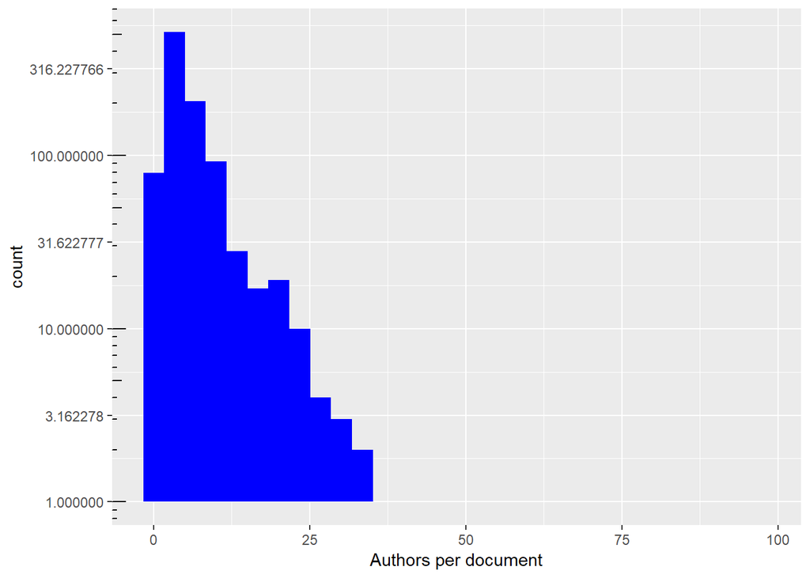

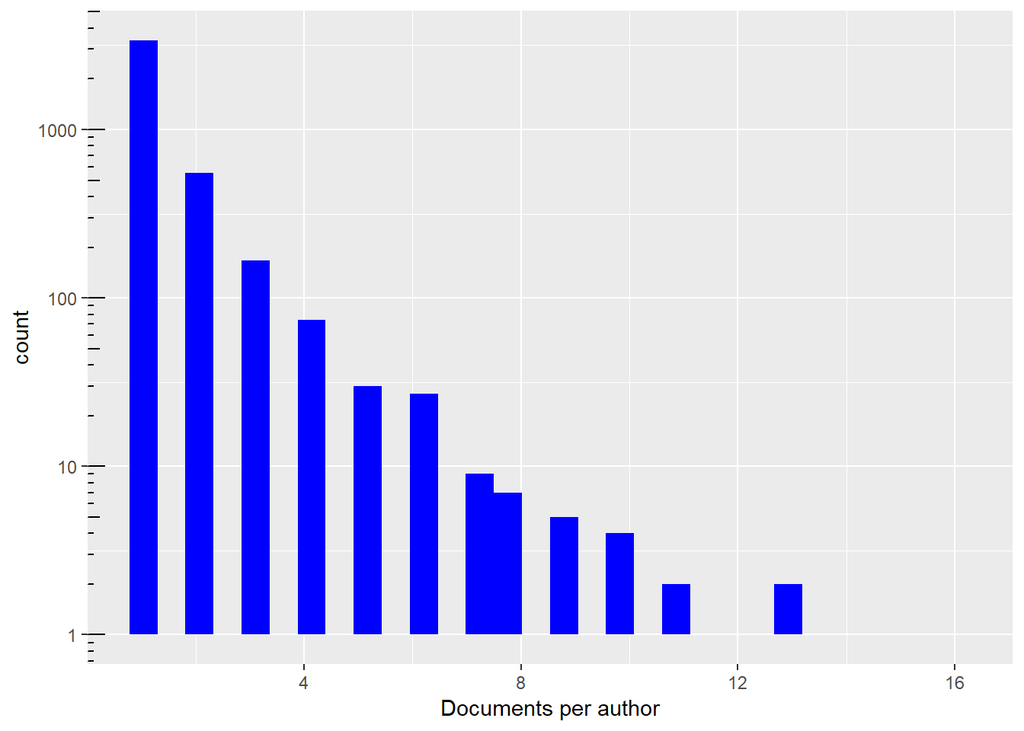

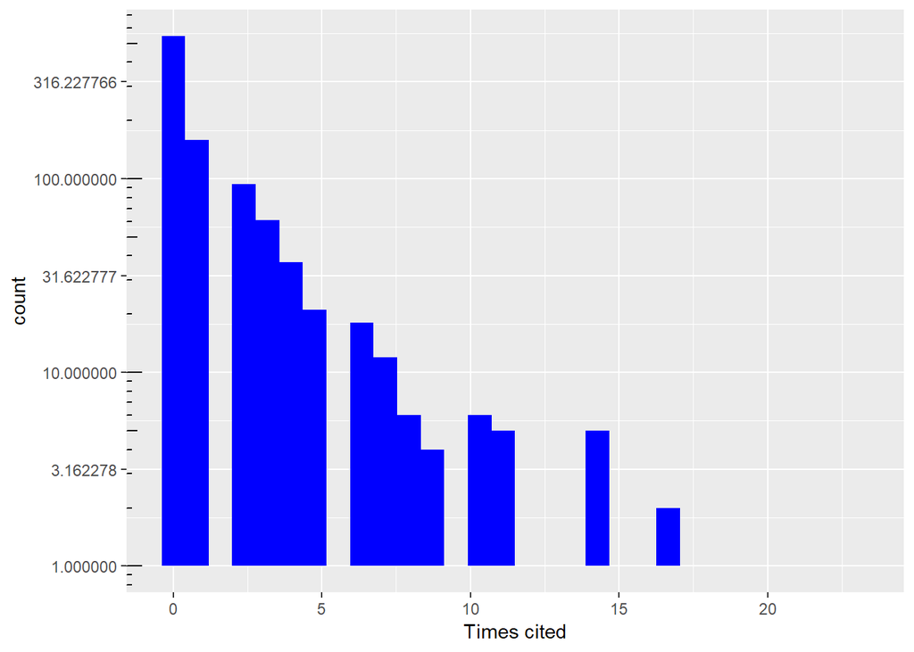

```r
plot(db)
```

### Sumario “wos.db”

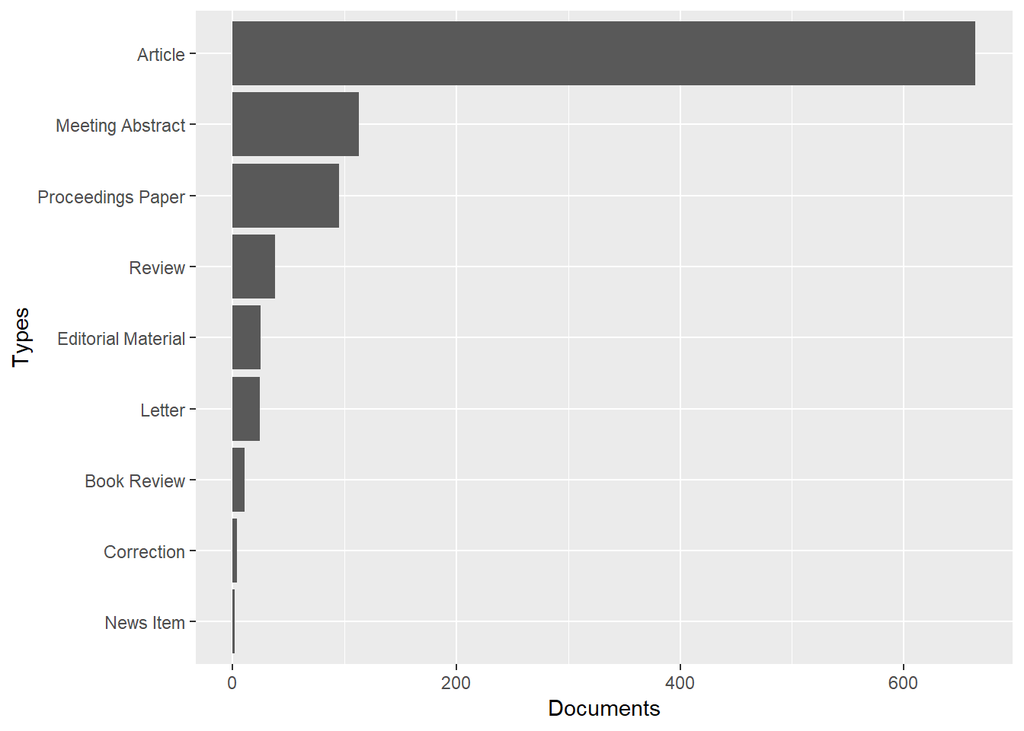

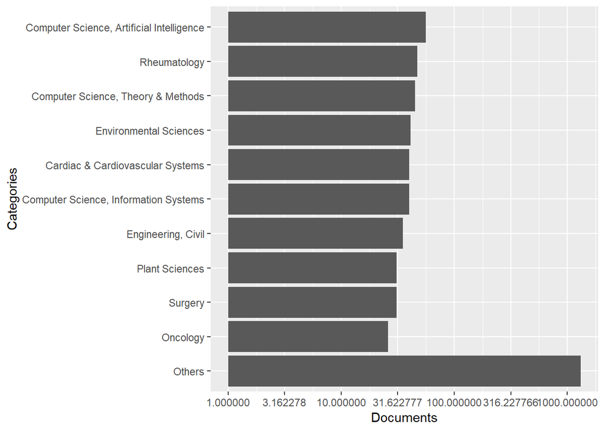

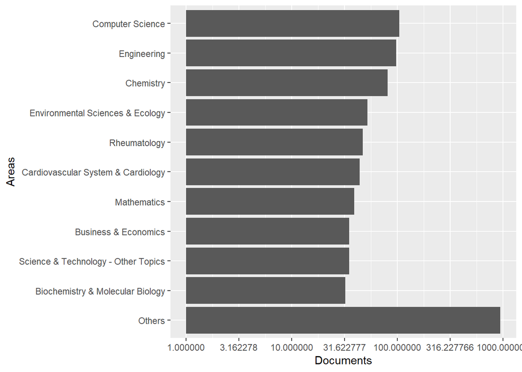

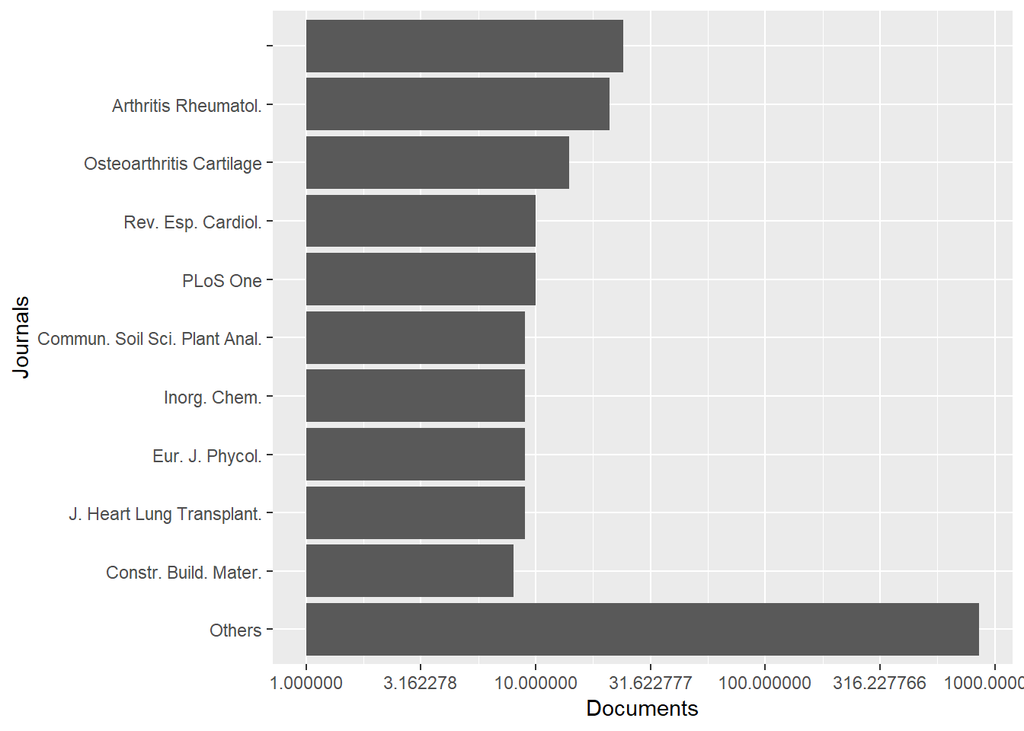

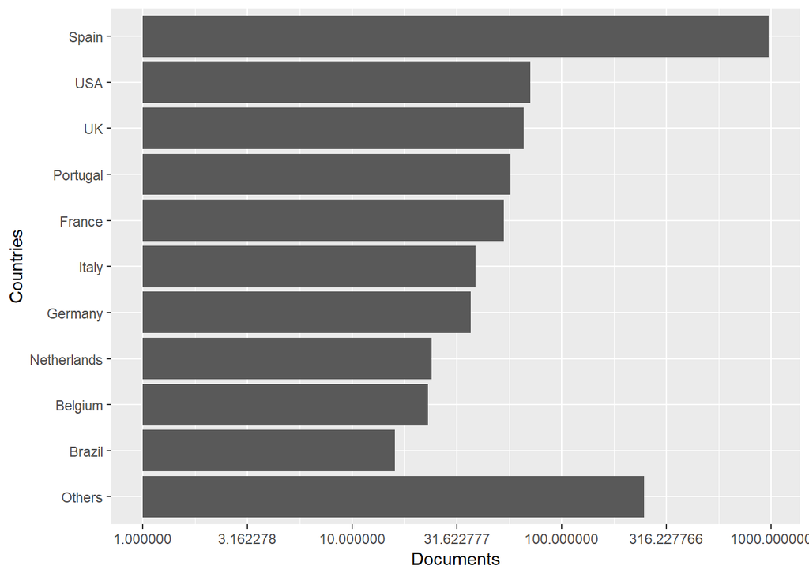

```r
plot(res1)
```

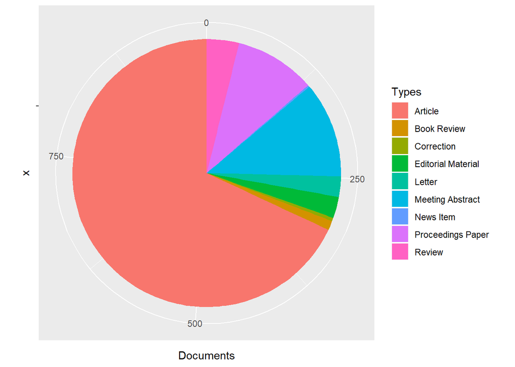

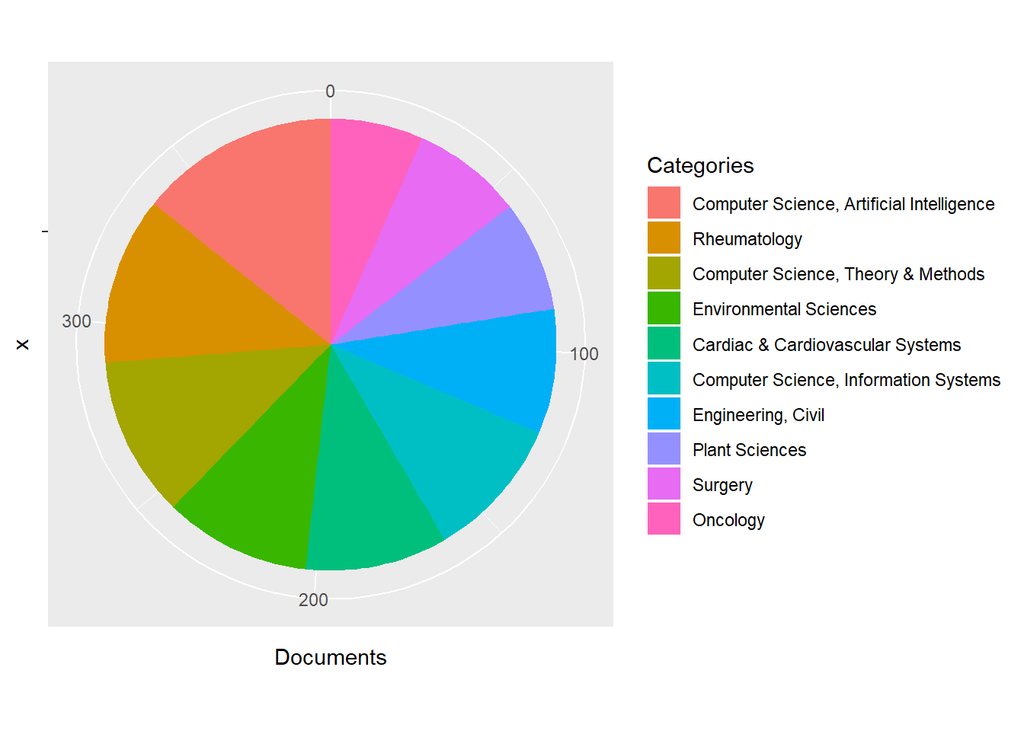

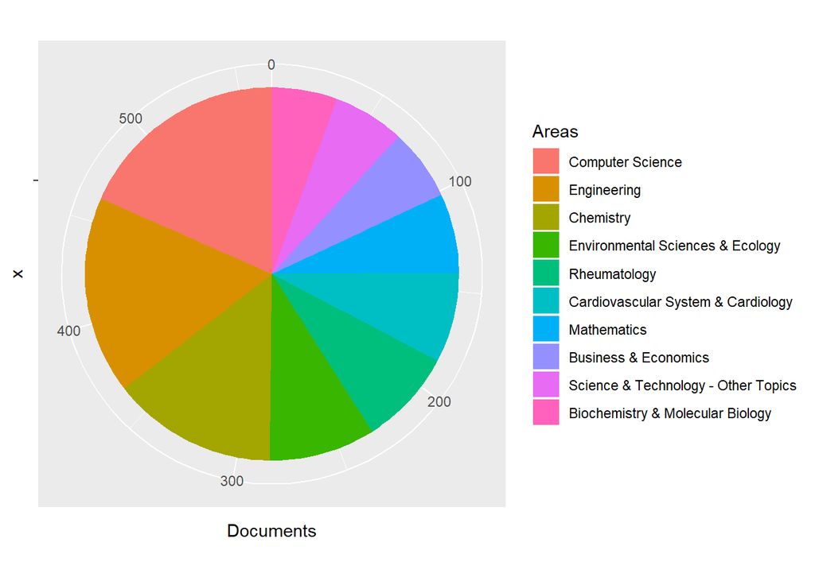

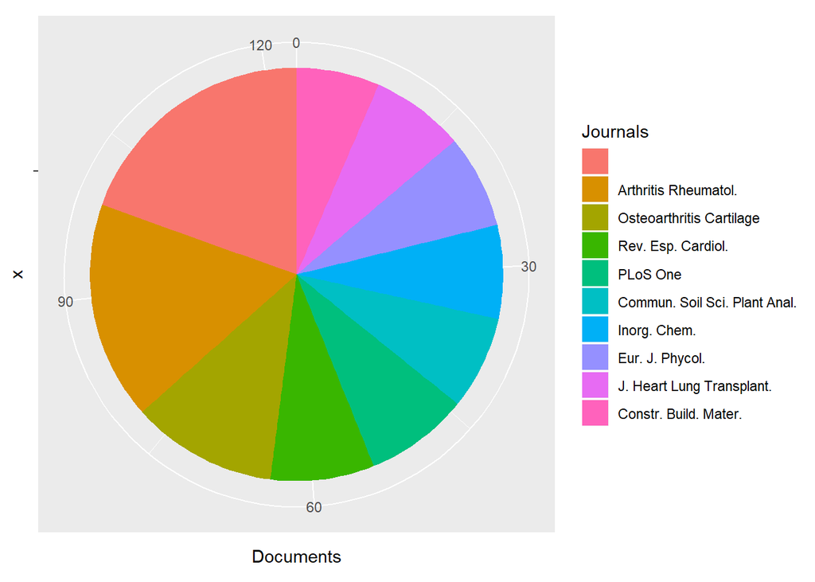

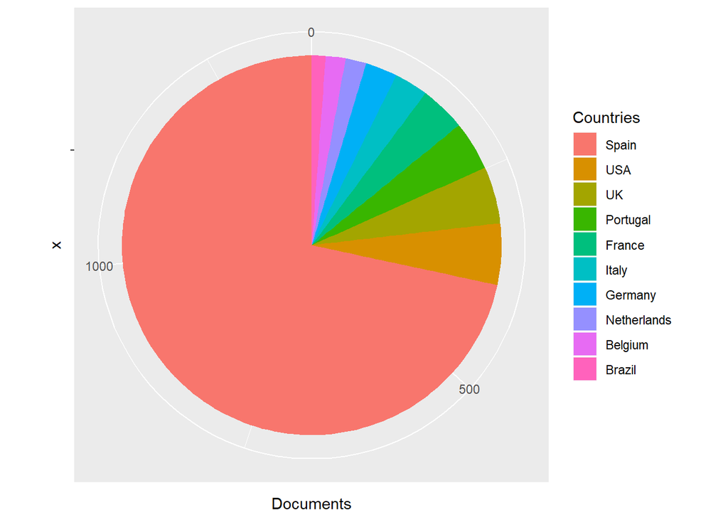

```r
plot(res1, pie = TRUE)
```

### Sumario por años

```
## geom_path: Each group consists of only one observation. Do you need to
## adjust the group aesthetic?
```

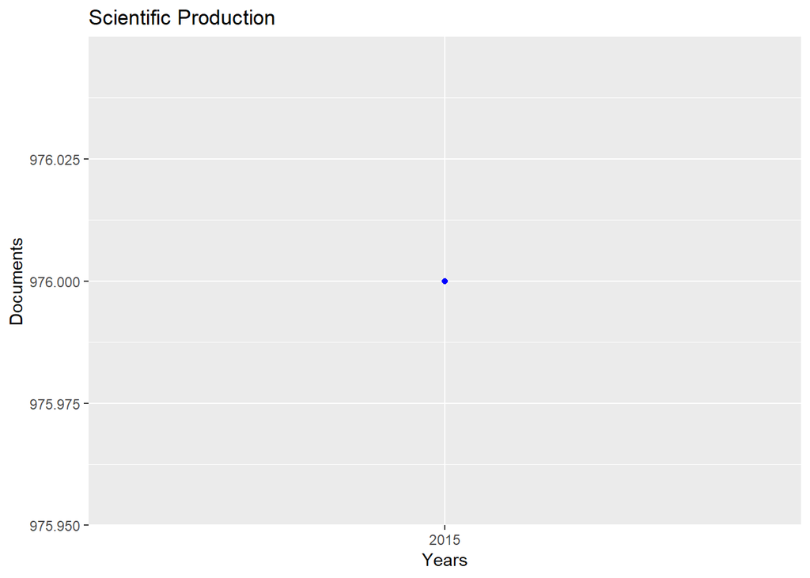

```
## geom_path: Each group consists of only one observation. Do you need to
## adjust the group aesthetic?
```

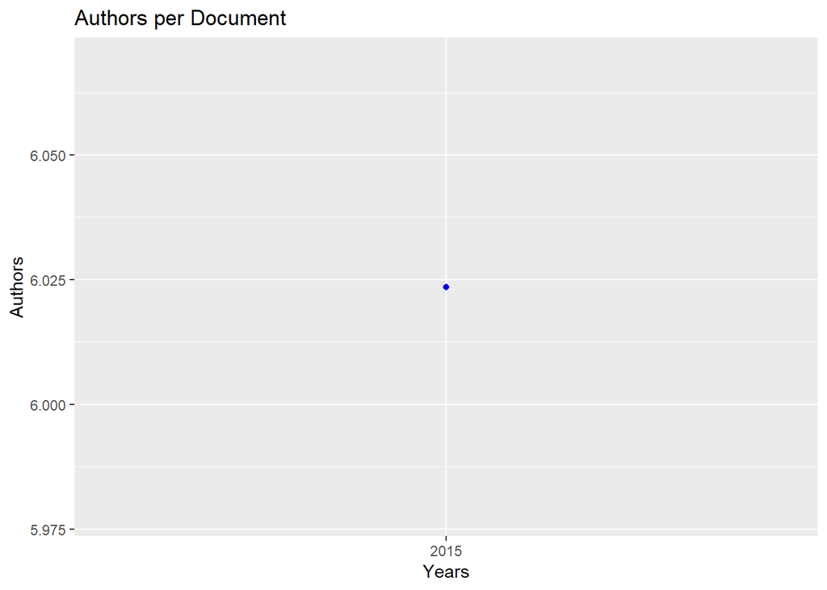

```
## geom_path: Each group consists of only one observation. Do you need to
## adjust the group aesthetic?
```

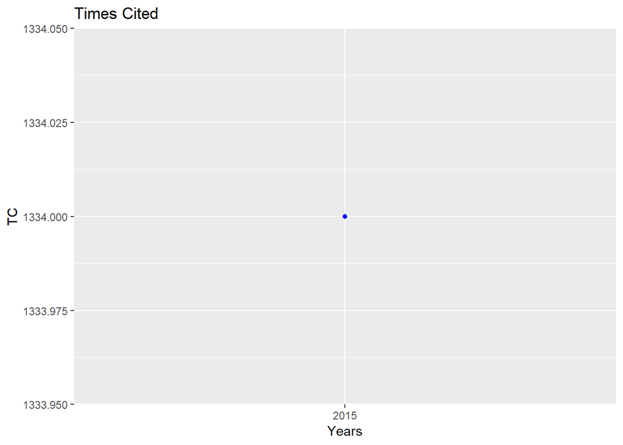

```r
plot(res2)
```

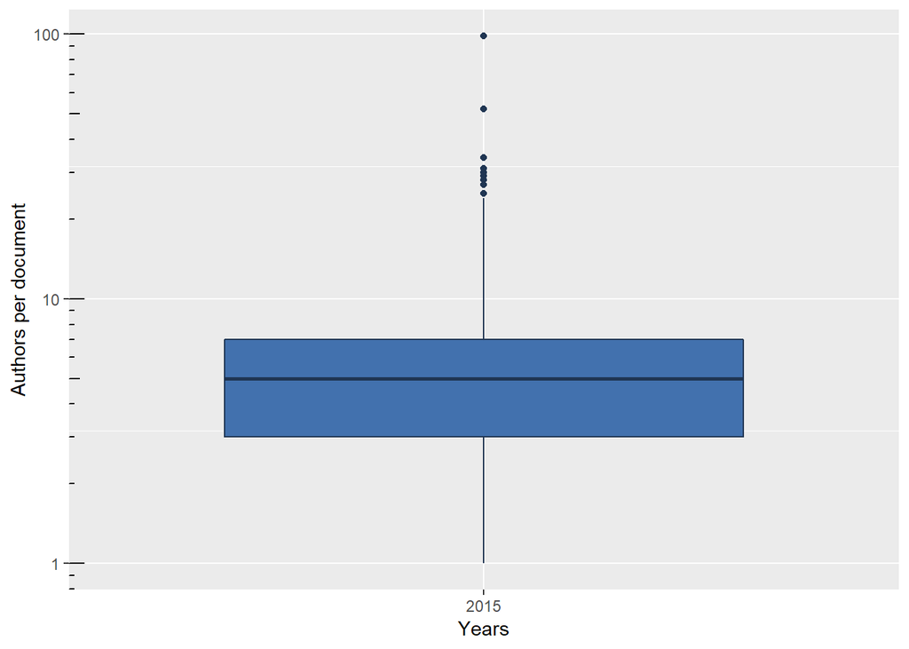

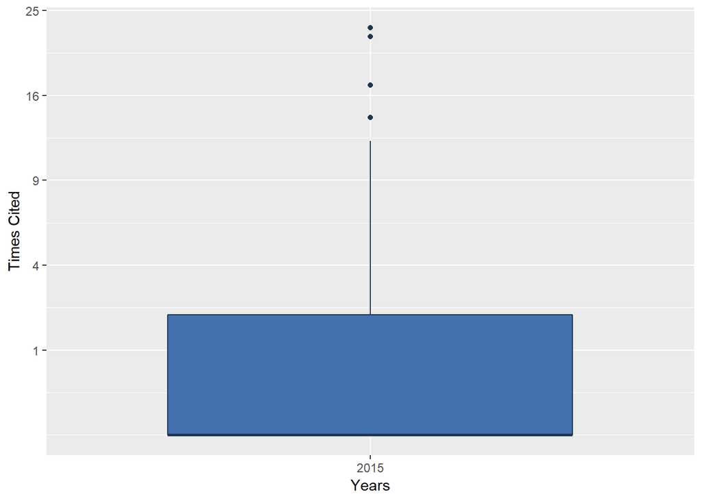

```r
plot(res2, boxplot = TRUE)
```

## Filtrado

### Funciones get

Buscar una persona concreta

```r
idAuthors <- get.idAuthors(db,AF == "Angel Bartolome, Miguel")
idAuthors
```

```
## named integer(0)
```

Buscar en nombres personas

```r
idAuthors <- get.idAuthors(db, grepl('Miguel A.', AF))
str(idAuthors)
```

```
##  Named int [1:6] 244 1931 2162 2208 3095 3442
##  - attr(*, "names")= chr [1:6] "Martinez-Prieto, Miguel A." "Cainzos, Miguel A." "Alvarez Rico, Miguel Angel" "Gonzalez-Gay, Miguel A." ...
```

```r
idAuthors[1:10]
```

```
##  Martinez-Prieto, Miguel A.          Cainzos, Miguel A.
##                         244                        1931
##  Alvarez Rico, Miguel Angel     Gonzalez-Gay, Miguel A.
##                        2162                        2208
## Miguel Anton-Aparicio, Luis            Rubio, Miguel A.
##                        3095                        3442
##                        <NA>                        <NA>
##                          NA                          NA
##                        <NA>                        <NA>
##                          NA                          NA
```

get.idAreas Devuelve códigos de las áreas Multiple conditions are combined with & (see ) Se puede emplear cualquier variable de la correspondiente tabla…

```r
get.idAreas(db,SC=='Mathematics')
```

```
## Mathematics
##          68
```

```r
get.idAreas(db,SC=='Mathematics'| SC=='Dermatology')
```

```
## Dermatology Mathematics
##          27          68
```

get.idCategories

```r
get.idCategories(db, grepl('Mathematics', WC))
```

```
##                                 Mathematics
##                                         117
##                        Mathematics, Applied
##                                         118
## Mathematics, Interdisciplinary Applications
##                                         119
```

get.idJournals

```r
get.idJournals(db,SO=='JOURNAL OF THE AMERICAN CHEMICAL SOCIETY')
```

```
## JOURNAL OF THE AMERICAN CHEMICAL SOCIETY
##                                        5
```

```r
get.idJournals(db,J9=='J AM CHEM SOC')
```

```
## JOURNAL OF THE AMERICAN CHEMICAL SOCIETY
##                                        5
```

### Obtener documentos de autores

Los indices anteriores se pueden combinar en `get.idDocs`

```r
idocs <- get.idDocs(db, idAuthors = idAuthors)
idocs
```

```
## [1] 289 326 334 336 555 663
```

Los índices de documentos se pueden utilizar como filtro p.e. en `summary`.

### Sumarios filtrados

Obtener sumario de autores:

```r
summary(db, idocs)
```

```
## Number of documents: 6
## Authors: 186
## Period: 2015
##
## Document types:
##         Documents
## Article         4
## Letter          1
## Review          1
##
## Number of authors per document:
##    Min. 1st Qu.  Median    Mean 3rd Qu.    Max.
##    5.00    9.25   11.00   31.00   42.00   98.00
##
## Number of documents per author:
##    Min. 1st Qu.  Median    Mean 3rd Qu.    Max.
##       1       1       1       1       1       1
##
## Number of times cited:
##    Min. 1st Qu.  Median    Mean 3rd Qu.    Max.
##   3.000   4.250   6.000   7.333  10.000  14.000
##
## Indexes:
## H G
## 4 6
##
## Top Categories:
##                                           Documents
## Surgery                                           3
## Computer Science, Artificial Intelligence         1
## Computer Science, Information Systems             1
## Emergency Medicine                                1
## Oncology                                          1
## Rheumatology                                      1
##
## Top Areas:
##                    Documents
## Surgery                    3
## Computer Science           1
## Emergency Medicine         1
```

[output cut: 10 more lines]

```
## World J. Emerg. Surg.         1
##
## Top Countries:
##             Documents
## Spain               6
## Australia           2
## Canada              2
## China               2
## Colombia            2
## Finland             2
## France              2
## Mexico              2
## Netherlands         2
## Portugal            2
## Others             37
```

Obtener sumario de autores por años:

```r
summary_year(db, idocs)
```

```
##
## Annual Scientific Production:
##
##      Documents
## 2015         6
##
## Annual Authors per Document:
##
##       Avg Median
##  2015  31     11
##
## Annual Times Cited:
##
##       Cites      Avg Median
##  2015    44 7.333333      6
```

## Indices autores

Obtener índices de múltiples autores

```r
TC.authors(db, idAuthors)
```

```
##                             H G
## Martinez-Prieto, Miguel A.  1 1
## Cainzos, Miguel A.          1 1
## Alvarez Rico, Miguel Angel  1 1
## Gonzalez-Gay, Miguel A.     1 1
## Miguel Anton-Aparicio, Luis 1 1
## Rubio, Miguel A.            1 1
```